# Risk Factor Analysis

## Outcome Variable

**Outcome Variable:** wast_rec90d

## Predictor Variables

**Intervention Variable:** predexfd6

**Adjustment Set:**

- arm
- sex
- brthmon
- W_mage
- meducyrs
- feducyrs
- hhwealth_quart
- hfoodsec
- W_mhtcm
- W_mwtkg
- W_mbmi
- vagbrth
- W_gagebrth
- W_birthwt
- W_birthlen
- W_nrooms
- month
- W_parity
- impfloor
- impsan
- safeh20
- delta_W_mage
- delta_meducyrs
- delta_feducyrs
- delta_hhwealth_quart
- delta_hfoodsec
- delta_W_mhtcm
- delta_W_mwtkg
- delta_W_mbmi
- delta_vagbrth
- delta_W_gagebrth
- delta_W_birthwt
- delta_W_birthlen
- delta_W_nrooms
- delta_month
- delta_W_parity
- delta_impfloor
- delta_impsan
- delta_safeh20

## Stratifying Variables

The analysis was stratified on these variable(s):

- agecat
- studyid
- country

## Data Summary

| agecat | studyid | country | predexfd6 | wast_rec90d | n_cell | n |
| --- | --- | --- | --- | --- | --- | --- |
| 0-24 months | CMC-V-BCS-2002 | INDIA | 1 | 0 | 7 | 16 |
| 0-24 months | CMC-V-BCS-2002 | INDIA | 1 | 1 | 9 | 16 |
| 0-24 months | CMC-V-BCS-2002 | INDIA | 0 | 0 | 0 | 16 |
| 0-24 months | CMC-V-BCS-2002 | INDIA | 0 | 1 | 0 | 16 |
| 0-24 months | EE | PAKISTAN | 1 | 0 | 15 | 34 |
| 0-24 months | EE | PAKISTAN | 1 | 1 | 16 | 34 |
| 0-24 months | EE | PAKISTAN | 0 | 0 | 0 | 34 |
| 0-24 months | EE | PAKISTAN | 0 | 1 | 3 | 34 |
| 0-24 months | GMS-Nepal | NEPAL | 1 | 0 | 192 | 594 |
| 0-24 months | GMS-Nepal | NEPAL | 1 | 1 | 251 | 594 |
| 0-24 months | GMS-Nepal | NEPAL | 0 | 0 | 70 | 594 |
| 0-24 months | GMS-Nepal | NEPAL | 0 | 1 | 81 | 594 |
| 0-24 months | IRC | INDIA | 1 | 0 | 0 | 19 |
| 0-24 months | IRC | INDIA | 1 | 1 | 0 | 19 |
| 0-24 months | IRC | INDIA | 0 | 0 | 11 | 19 |
| 0-24 months | IRC | INDIA | 0 | 1 | 8 | 19 |
| 0-24 months | JiVitA-3 | BANGLADESH | 1 | 0 | 2004 | 4526 |
| 0-24 months | JiVitA-3 | BANGLADESH | 1 | 1 | 1506 | 4526 |
| 0-24 months | JiVitA-3 | BANGLADESH | 0 | 0 | 594 | 4526 |
| 0-24 months | JiVitA-3 | BANGLADESH | 0 | 1 | 422 | 4526 |
| 0-24 months | JiVitA-4 | BANGLADESH | 1 | 0 | 986 | 1841 |
| 0-24 months | JiVitA-4 | BANGLADESH | 1 | 1 | 372 | 1841 |
| 0-24 months | JiVitA-4 | BANGLADESH | 0 | 0 | 349 | 1841 |
| 0-24 months | JiVitA-4 | BANGLADESH | 0 | 1 | 134 | 1841 |
| 0-24 months | Keneba | GAMBIA | 1 | 0 | 180 | 1602 |
| 0-24 months | Keneba | GAMBIA | 1 | 1 | 316 | 1602 |
| 0-24 months | Keneba | GAMBIA | 0 | 0 | 406 | 1602 |
| 0-24 months | Keneba | GAMBIA | 0 | 1 | 700 | 1602 |
| 0-24 months | LCNI-5 | MALAWI | 1 | 0 | 5 | 34 |
| 0-24 months | LCNI-5 | MALAWI | 1 | 1 | 2 | 34 |

[output cut: 186 more lines]

The following strata were considered:

- agecat: 0-24 months, studyid: CMC-V-BCS-2002, country: INDIA
- agecat: 0-24 months, studyid: EE, country: PAKISTAN
- agecat: 0-24 months, studyid: GMS-Nepal, country: NEPAL
- agecat: 0-24 months, studyid: IRC, country: INDIA
- agecat: 0-24 months, studyid: JiVitA-3, country: BANGLADESH
- agecat: 0-24 months, studyid: JiVitA-4, country: BANGLADESH
- agecat: 0-24 months, studyid: Keneba, country: GAMBIA
- agecat: 0-24 months, studyid: LCNI-5, country: MALAWI
- agecat: 0-24 months, studyid: MAL-ED, country: BANGLADESH
- agecat: 0-24 months, studyid: MAL-ED, country: BRAZIL
- agecat: 0-24 months, studyid: MAL-ED, country: INDIA
- agecat: 0-24 months, studyid: MAL-ED, country: NEPAL
- agecat: 0-24 months, studyid: MAL-ED, country: PERU
- agecat: 0-24 months, studyid: MAL-ED, country: SOUTH AFRICA
- agecat: 0-24 months, studyid: MAL-ED, country: TANZANIA, UNITED REPUBLIC OF
- agecat: 0-24 months, studyid: PROVIDE, country: BANGLADESH
- agecat: 0-24 months, studyid: SAS-CompFeed, country: INDIA
- agecat: 0-24 months, studyid: SAS-FoodSuppl, country: INDIA
- agecat: 0-6 months, studyid: CMC-V-BCS-2002, country: INDIA
- agecat: 0-6 months, studyid: EE, country: PAKISTAN
- agecat: 0-6 months, studyid: GMS-Nepal, country: NEPAL
- agecat: 0-6 months, studyid: IRC, country: INDIA
- agecat: 0-6 months, studyid: JiVitA-3, country: BANGLADESH
- agecat: 0-6 months, studyid: JiVitA-4, country: BANGLADESH
- agecat: 0-6 months, studyid: Keneba, country: GAMBIA
- agecat: 0-6 months, studyid: LCNI-5, country: MALAWI
- agecat: 0-6 months, studyid: MAL-ED, country: BANGLADESH
- agecat: 0-6 months, studyid: MAL-ED, country: BRAZIL
- agecat: 0-6 months, studyid: MAL-ED, country: INDIA
- agecat: 0-6 months, studyid: MAL-ED, country: NEPAL
- agecat: 0-6 months, studyid: MAL-ED, country: PERU
- agecat: 0-6 months, studyid: MAL-ED, country: SOUTH AFRICA
- agecat: 0-6 months, studyid: MAL-ED, country: TANZANIA, UNITED REPUBLIC OF
- agecat: 0-6 months, studyid: PROVIDE, country: BANGLADESH
- agecat: 0-6 months, studyid: SAS-CompFeed, country: INDIA
- agecat: 0-6 months, studyid: SAS-FoodSuppl, country: INDIA
- agecat: 6-24 months, studyid: CMC-V-BCS-2002, country: INDIA
- agecat: 6-24 months, studyid: EE, country: PAKISTAN
- agecat: 6-24 months, studyid: GMS-Nepal, country: NEPAL
- agecat: 6-24 months, studyid: IRC, country: INDIA
- agecat: 6-24 months, studyid: JiVitA-3, country: BANGLADESH
- agecat: 6-24 months, studyid: JiVitA-4, country: BANGLADESH
- agecat: 6-24 months, studyid: Keneba, country: GAMBIA
- agecat: 6-24 months, studyid: LCNI-5, country: MALAWI
- agecat: 6-24 months, studyid: MAL-ED, country: BANGLADESH
- agecat: 6-24 months, studyid: MAL-ED, country: BRAZIL
- agecat: 6-24 months, studyid: MAL-ED, country: INDIA
- agecat: 6-24 months, studyid: MAL-ED, country: NEPAL
- agecat: 6-24 months, studyid: MAL-ED, country: PERU
- agecat: 6-24 months, studyid: MAL-ED, country: SOUTH AFRICA
- agecat: 6-24 months, studyid: MAL-ED, country: TANZANIA, UNITED REPUBLIC OF
- agecat: 6-24 months, studyid: PROVIDE, country: BANGLADESH
- agecat: 6-24 months, studyid: SAS-CompFeed, country: INDIA
- agecat: 6-24 months, studyid: SAS-FoodSuppl, country: INDIA

### Dropped Strata

Some strata were dropped due to rare outcomes:

- agecat: 0-24 months, studyid: CMC-V-BCS-2002, country: INDIA
- agecat: 0-24 months, studyid: EE, country: PAKISTAN
- agecat: 0-24 months, studyid: IRC, country: INDIA
- agecat: 0-24 months, studyid: LCNI-5, country: MALAWI
- agecat: 0-24 months, studyid: MAL-ED, country: BRAZIL
- agecat: 0-24 months, studyid: MAL-ED, country: INDIA
- agecat: 0-24 months, studyid: MAL-ED, country: NEPAL
- agecat: 0-24 months, studyid: MAL-ED, country: PERU
- agecat: 0-24 months, studyid: MAL-ED, country: SOUTH AFRICA
- agecat: 0-24 months, studyid: MAL-ED, country: TANZANIA, UNITED REPUBLIC OF
- agecat: 0-24 months, studyid: SAS-FoodSuppl, country: INDIA
- agecat: 0-6 months, studyid: CMC-V-BCS-2002, country: INDIA
- agecat: 0-6 months, studyid: EE, country: PAKISTAN
- agecat: 0-6 months, studyid: IRC, country: INDIA
- agecat: 0-6 months, studyid: LCNI-5, country: MALAWI
- agecat: 0-6 months, studyid: MAL-ED, country: BANGLADESH
- agecat: 0-6 months, studyid: MAL-ED, country: BRAZIL
- agecat: 0-6 months, studyid: MAL-ED, country: INDIA
- agecat: 0-6 months, studyid: MAL-ED, country: NEPAL
- agecat: 0-6 months, studyid: MAL-ED, country: PERU
- agecat: 0-6 months, studyid: MAL-ED, country: SOUTH AFRICA
- agecat: 0-6 months, studyid: MAL-ED, country: TANZANIA, UNITED REPUBLIC OF
- agecat: 0-6 months, studyid: SAS-CompFeed, country: INDIA
- agecat: 0-6 months, studyid: SAS-FoodSuppl, country: INDIA
- agecat: 6-24 months, studyid: CMC-V-BCS-2002, country: INDIA
- agecat: 6-24 months, studyid: EE, country: PAKISTAN
- agecat: 6-24 months, studyid: IRC, country: INDIA
- agecat: 6-24 months, studyid: JiVitA-3, country: BANGLADESH
- agecat: 6-24 months, studyid: LCNI-5, country: MALAWI
- agecat: 6-24 months, studyid: MAL-ED, country: BRAZIL
- agecat: 6-24 months, studyid: MAL-ED, country: INDIA
- agecat: 6-24 months, studyid: MAL-ED, country: NEPAL
- agecat: 6-24 months, studyid: MAL-ED, country: PERU
- agecat: 6-24 months, studyid: MAL-ED, country: SOUTH AFRICA
- agecat: 6-24 months, studyid: MAL-ED, country: TANZANIA, UNITED REPUBLIC OF
- agecat: 6-24 months, studyid: SAS-CompFeed, country: INDIA
- agecat: 6-24 months, studyid: SAS-FoodSuppl, country: INDIA

## Methods Detail

We’re interested in the causal parameters $E[Y_a]$ for all values of $a \in \mathcal{A}$. These parameters represent the mean outcome if, possibly contrary to fact, we intervened to set all units to have $A=a$. Under the randomization and positivity assumptions, these are identified by the statistical parameters $\psi_a=E_W[E_{Y|A,W}(Y|A=a,W)]$. In addition, we’re interested in the mean of $Y$, $E[Y]$ under no intervention (the observed mean). We will estimate these parameters by using SuperLearner to fit the relevant likelihood factors – $E_{Y|A,W}(Y|A=a,W)$ and $p(A=a|W)$, and then updating our likelihood fit using a joint TMLE.

For unadjusted analyses ($W=\{\}$), initial likelihoods were estimated using Lrnr_glm to estimate the simple $E(Y|A)$ and Lrnr_mean to estimate $p(A)$. For adjusted analyses, a small library containing Lrnr_glmnet, Lrnr_xgboost, and Lrnr_mean was used.

Having estimated these parameters, we will then use the delta method to estimate relative risks and attributable risks relative to a prespecified baseline level of $A$.

# Results Detail

## Results Plots

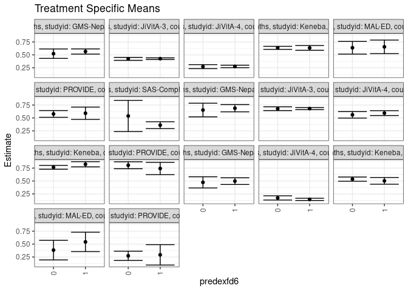

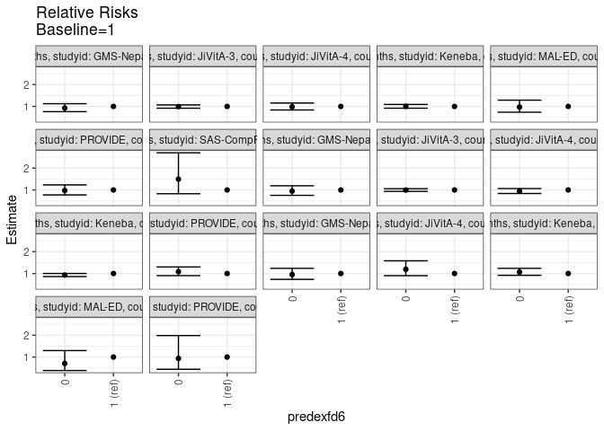

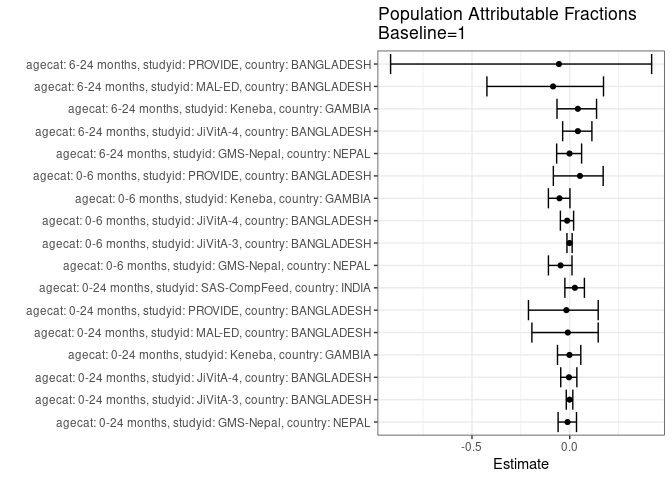

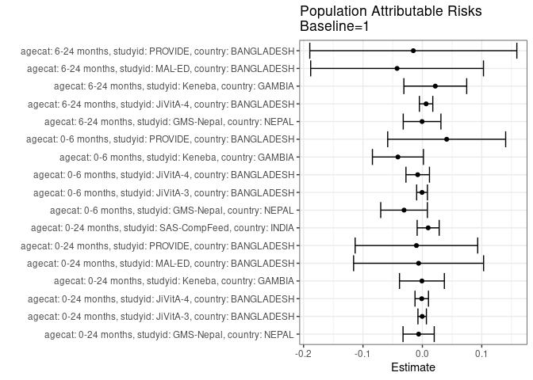

## Results Table

### Parameter: TSM

| agecat | studyid | country | intervention_level | baseline_level | estimate | ci_lower | ci_upper |
| --- | --- | --- | --- | --- | --- | --- | --- |
| 0-24 months | GMS-Nepal | NEPAL | 1 | NA | 0.5652442 | 0.5151641 | 0.6153243 |
| 0-24 months | GMS-Nepal | NEPAL | 0 | NA | 0.5230226 | 0.4317787 | 0.6142665 |
| 0-24 months | JiVitA-3 | BANGLADESH | 1 | NA | 0.4263341 | 0.4103218 | 0.4423463 |
| 0-24 months | JiVitA-3 | BANGLADESH | 0 | NA | 0.4225798 | 0.3939567 | 0.4512029 |
| 0-24 months | JiVitA-4 | BANGLADESH | 1 | NA | 0.2759336 | 0.2519364 | 0.2999309 |
| 0-24 months | JiVitA-4 | BANGLADESH | 0 | NA | 0.2717178 | 0.2329696 | 0.3104659 |
| 0-24 months | Keneba | GAMBIA | 1 | NA | 0.6349621 | 0.5889777 | 0.6809466 |
| 0-24 months | Keneba | GAMBIA | 0 | NA | 0.6357310 | 0.6060056 | 0.6654565 |
| 0-24 months | MAL-ED | BANGLADESH | 1 | NA | 0.6554847 | 0.5244332 | 0.7865363 |
| 0-24 months | MAL-ED | BANGLADESH | 0 | NA | 0.6379512 | 0.5148008 | 0.7611015 |
| 0-24 months | PROVIDE | BANGLADESH | 1 | NA | 0.5911815 | 0.4715110 | 0.7108520 |
| 0-24 months | PROVIDE | BANGLADESH | 0 | NA | 0.5773280 | 0.5124434 | 0.6422126 |
| 0-24 months | SAS-CompFeed | INDIA | 1 | NA | 0.3600000 | 0.2937351 | 0.4262649 |
| 0-24 months | SAS-CompFeed | INDIA | 0 | NA | 0.5384615 | 0.2364546 | 0.8404685 |
| 0-6 months | GMS-Nepal | NEPAL | 1 | NA | 0.6887434 | 0.6179844 | 0.7595023 |
| 0-6 months | GMS-Nepal | NEPAL | 0 | NA | 0.6534965 | 0.5213382 | 0.7856547 |
| 0-6 months | JiVitA-3 | BANGLADESH | 1 | NA | 0.6813507 | 0.6620273 | 0.7006740 |
| 0-6 months | JiVitA-3 | BANGLADESH | 0 | NA | 0.6787296 | 0.6420077 | 0.7154516 |
| 0-6 months | JiVitA-4 | BANGLADESH | 1 | NA | 0.5934036 | 0.5462741 | 0.6405331 |
| 0-6 months | JiVitA-4 | BANGLADESH | 0 | NA | 0.5609522 | 0.4972142 | 0.6246903 |
| 0-6 months | Keneba | GAMBIA | 1 | NA | 0.8243480 | 0.7740799 | 0.8746161 |
| 0-6 months | Keneba | GAMBIA | 0 | NA | 0.7654510 | 0.7284609 | 0.8024411 |
| 0-6 months | PROVIDE | BANGLADESH | 1 | NA | 0.7428750 | 0.6237490 | 0.8620010 |
| 0-6 months | PROVIDE | BANGLADESH | 0 | NA | 0.8052587 | 0.7378427 | 0.8726746 |
| 6-24 months | GMS-Nepal | NEPAL | 1 | NA | 0.4977769 | 0.4330475 | 0.5625063 |
| 6-24 months | GMS-Nepal | NEPAL | 0 | NA | 0.4738220 | 0.3656691 | 0.5819750 |
| 6-24 months | JiVitA-4 | BANGLADESH | 1 | NA | 0.1443185 | 0.1228516 | 0.1657855 |
| 6-24 months | JiVitA-4 | BANGLADESH | 0 | NA | 0.1723078 | 0.1313948 | 0.2132208 |
| 6-24 months | Keneba | GAMBIA | 1 | NA | 0.5031469 | 0.4381863 | 0.5681076 |
| 6-24 months | Keneba | GAMBIA | 0 | NA | 0.5364807 | 0.4956978 | 0.5772637 |
| 6-24 months | MAL-ED | BANGLADESH | 1 | NA | 0.5425939 | 0.3548019 | 0.7303858 |
| 6-24 months | MAL-ED | BANGLADESH | 0 | NA | 0.3832980 | 0.1935620 | 0.5730341 |
| 6-24 months | PROVIDE | BANGLADESH | 1 | NA | 0.2916667 | 0.0943448 | 0.4889886 |
| 6-24 months | PROVIDE | BANGLADESH | 0 | NA | 0.2727273 | 0.1836941 | 0.3617604 |

### Parameter: E(Y)

| agecat | studyid | country | intervention_level | baseline_level | estimate | ci_lower | ci_upper |
| --- | --- | --- | --- | --- | --- | --- | --- |
| 0-24 months | GMS-Nepal | NEPAL | NA | NA | 0.5589226 | 0.5151400 | 0.6027051 |
| 0-24 months | JiVitA-3 | BANGLADESH | NA | NA | 0.4259832 | 0.4115786 | 0.4403878 |
| 0-24 months | JiVitA-4 | BANGLADESH | NA | NA | 0.2748506 | 0.2539041 | 0.2957971 |
| 0-24 months | Keneba | GAMBIA | NA | NA | 0.6342072 | 0.6090524 | 0.6593621 |
| 0-24 months | MAL-ED | BANGLADESH | NA | NA | 0.6491228 | 0.5591034 | 0.7391422 |
| 0-24 months | PROVIDE | BANGLADESH | NA | NA | 0.5811688 | 0.5245443 | 0.6377934 |
| 0-24 months | SAS-CompFeed | INDIA | NA | NA | 0.3697479 | 0.3045176 | 0.4349782 |
| 0-6 months | GMS-Nepal | NEPAL | NA | NA | 0.6578947 | 0.5956613 | 0.7201282 |
| 0-6 months | JiVitA-3 | BANGLADESH | NA | NA | 0.6807910 | 0.6636189 | 0.6979630 |
| 0-6 months | JiVitA-4 | BANGLADESH | NA | NA | 0.5855513 | 0.5434121 | 0.6276905 |
| 0-6 months | Keneba | GAMBIA | NA | NA | 0.7831858 | 0.7527627 | 0.8136090 |
| 0-6 months | PROVIDE | BANGLADESH | NA | NA | 0.7837838 | 0.7252863 | 0.8422812 |
| 6-24 months | GMS-Nepal | NEPAL | NA | NA | 0.4972678 | 0.4417121 | 0.5528234 |
| 6-24 months | JiVitA-4 | BANGLADESH | NA | NA | 0.1505703 | 0.1316510 | 0.1694897 |
| 6-24 months | Keneba | GAMBIA | NA | NA | 0.5248918 | 0.4904236 | 0.5593599 |
| 6-24 months | MAL-ED | BANGLADESH | NA | NA | 0.5000000 | 0.3630175 | 0.6369825 |
| 6-24 months | PROVIDE | BANGLADESH | NA | NA | 0.2764228 | 0.1950773 | 0.3577682 |

### Parameter: RR

| agecat | studyid | country | intervention_level | baseline_level | estimate | ci_lower | ci_upper |
| --- | --- | --- | --- | --- | --- | --- | --- |
| 0-24 months | GMS-Nepal | NEPAL | 1 | 1 | 1.0000000 | 1.0000000 | 1.000000 |
| 0-24 months | GMS-Nepal | NEPAL | 0 | 1 | 0.9253038 | 0.7609758 | 1.125117 |
| 0-24 months | JiVitA-3 | BANGLADESH | 1 | 1 | 1.0000000 | 1.0000000 | 1.000000 |
| 0-24 months | JiVitA-3 | BANGLADESH | 0 | 1 | 0.9911941 | 0.9196458 | 1.068309 |
| 0-24 months | JiVitA-4 | BANGLADESH | 1 | 1 | 1.0000000 | 1.0000000 | 1.000000 |
| 0-24 months | JiVitA-4 | BANGLADESH | 0 | 1 | 0.9847214 | 0.8388997 | 1.155890 |
| 0-24 months | Keneba | GAMBIA | 1 | 1 | 1.0000000 | 1.0000000 | 1.000000 |
| 0-24 months | Keneba | GAMBIA | 0 | 1 | 1.0012109 | 0.9191321 | 1.090619 |
| 0-24 months | MAL-ED | BANGLADESH | 1 | 1 | 1.0000000 | 1.0000000 | 1.000000 |
| 0-24 months | MAL-ED | BANGLADESH | 0 | 1 | 0.9732510 | 0.7365999 | 1.285932 |
| 0-24 months | PROVIDE | BANGLADESH | 1 | 1 | 1.0000000 | 1.0000000 | 1.000000 |
| 0-24 months | PROVIDE | BANGLADESH | 0 | 1 | 0.9765664 | 0.7743746 | 1.231551 |
| 0-24 months | SAS-CompFeed | INDIA | 1 | 1 | 1.0000000 | 1.0000000 | 1.000000 |
| 0-24 months | SAS-CompFeed | INDIA | 0 | 1 | 1.4957265 | 0.8288715 | 2.699089 |
| 0-6 months | GMS-Nepal | NEPAL | 1 | 1 | 1.0000000 | 1.0000000 | 1.000000 |
| 0-6 months | GMS-Nepal | NEPAL | 0 | 1 | 0.9488244 | 0.7548457 | 1.192651 |
| 0-6 months | JiVitA-3 | BANGLADESH | 1 | 1 | 1.0000000 | 1.0000000 | 1.000000 |
| 0-6 months | JiVitA-3 | BANGLADESH | 0 | 1 | 0.9961532 | 0.9374016 | 1.058587 |
| 0-6 months | JiVitA-4 | BANGLADESH | 1 | 1 | 1.0000000 | 1.0000000 | 1.000000 |
| 0-6 months | JiVitA-4 | BANGLADESH | 0 | 1 | 0.9453131 | 0.8382760 | 1.066018 |
| 0-6 months | Keneba | GAMBIA | 1 | 1 | 1.0000000 | 1.0000000 | 1.000000 |
| 0-6 months | Keneba | GAMBIA | 0 | 1 | 0.9285532 | 0.8603721 | 1.002137 |
| 0-6 months | PROVIDE | BANGLADESH | 1 | 1 | 1.0000000 | 1.0000000 | 1.000000 |
| 0-6 months | PROVIDE | BANGLADESH | 0 | 1 | 1.0839760 | 0.9043806 | 1.299236 |
| 6-24 months | GMS-Nepal | NEPAL | 1 | 1 | 1.0000000 | 1.0000000 | 1.000000 |
| 6-24 months | GMS-Nepal | NEPAL | 0 | 1 | 0.9518762 | 0.7326450 | 1.236709 |
| 6-24 months | JiVitA-4 | BANGLADESH | 1 | 1 | 1.0000000 | 1.0000000 | 1.000000 |
| 6-24 months | JiVitA-4 | BANGLADESH | 0 | 1 | 1.1939409 | 0.9021170 | 1.580166 |
| 6-24 months | Keneba | GAMBIA | 1 | 1 | 1.0000000 | 1.0000000 | 1.000000 |
| 6-24 months | Keneba | GAMBIA | 0 | 1 | 1.0662506 | 0.9187306 | 1.237458 |
| 6-24 months | MAL-ED | BANGLADESH | 1 | 1 | 1.0000000 | 1.0000000 | 1.000000 |
| 6-24 months | MAL-ED | BANGLADESH | 0 | 1 | 0.7064180 | 0.3847560 | 1.296994 |
| 6-24 months | PROVIDE | BANGLADESH | 1 | 1 | 1.0000000 | 1.0000000 | 1.000000 |
| 6-24 months | PROVIDE | BANGLADESH | 0 | 1 | 0.9350649 | 0.4411401 | 1.982015 |

### Parameter: PAR

| agecat | studyid | country | intervention_level | baseline_level | estimate | ci_lower | ci_upper |
| --- | --- | --- | --- | --- | --- | --- | --- |
| 0-24 months | GMS-Nepal | NEPAL | 1 | NA | -0.0063216 | -0.0325768 | 0.0199336 |
| 0-24 months | JiVitA-3 | BANGLADESH | 1 | NA | -0.0003508 | -0.0074721 | 0.0067704 |
| 0-24 months | JiVitA-4 | BANGLADESH | 1 | NA | -0.0010830 | -0.0124198 | 0.0102537 |
| 0-24 months | Keneba | GAMBIA | 1 | NA | -0.0007549 | -0.0385344 | 0.0370246 |
| 0-24 months | MAL-ED | BANGLADESH | 1 | NA | -0.0063619 | -0.1157963 | 0.1030724 |
| 0-24 months | PROVIDE | BANGLADESH | 1 | NA | -0.0100127 | -0.1131933 | 0.0931680 |
| 0-24 months | SAS-CompFeed | INDIA | 1 | NA | 0.0097479 | -0.0087899 | 0.0282857 |
| 0-6 months | GMS-Nepal | NEPAL | 1 | NA | -0.0308486 | -0.0701428 | 0.0084456 |
| 0-6 months | JiVitA-3 | BANGLADESH | 1 | NA | -0.0005597 | -0.0096192 | 0.0084998 |
| 0-6 months | JiVitA-4 | BANGLADESH | 1 | NA | -0.0078523 | -0.0276445 | 0.0119399 |
| 0-6 months | Keneba | GAMBIA | 1 | NA | -0.0411622 | -0.0841017 | 0.0017773 |
| 0-6 months | PROVIDE | BANGLADESH | 1 | NA | 0.0409088 | -0.0583926 | 0.1402101 |
| 6-24 months | GMS-Nepal | NEPAL | 1 | NA | -0.0005092 | -0.0322370 | 0.0312187 |
| 6-24 months | JiVitA-4 | BANGLADESH | 1 | NA | 0.0062518 | -0.0050214 | 0.0175250 |
| 6-24 months | Keneba | GAMBIA | 1 | NA | 0.0217448 | -0.0311445 | 0.0746341 |
| 6-24 months | MAL-ED | BANGLADESH | 1 | NA | -0.0425939 | -0.1880588 | 0.1028711 |
| 6-24 months | PROVIDE | BANGLADESH | 1 | NA | -0.0152439 | -0.1895523 | 0.1590645 |

### Parameter: PAF

| agecat | studyid | country | intervention_level | baseline_level | estimate | ci_lower | ci_upper |
| --- | --- | --- | --- | --- | --- | --- | --- |
| 0-24 months | GMS-Nepal | NEPAL | 1 | NA | -0.0113104 | -0.0594415 | 0.0346341 |
| 0-24 months | JiVitA-3 | BANGLADESH | 1 | NA | -0.0008236 | -0.0176816 | 0.0157551 |
| 0-24 months | JiVitA-4 | BANGLADESH | 1 | NA | -0.0039404 | -0.0460419 | 0.0364666 |
| 0-24 months | Keneba | GAMBIA | 1 | NA | -0.0011903 | -0.0625663 | 0.0566405 |
| 0-24 months | MAL-ED | BANGLADESH | 1 | NA | -0.0098008 | -0.1935220 | 0.1456398 |
| 0-24 months | PROVIDE | BANGLADESH | 1 | NA | -0.0172285 | -0.2111331 | 0.1456316 |
| 0-24 months | SAS-CompFeed | INDIA | 1 | NA | 0.0263636 | -0.0248925 | 0.0750564 |
| 0-6 months | GMS-Nepal | NEPAL | 1 | NA | -0.0468899 | -0.1089195 | 0.0116700 |
| 0-6 months | JiVitA-3 | BANGLADESH | 1 | NA | -0.0008221 | -0.0142186 | 0.0123974 |
| 0-6 months | JiVitA-4 | BANGLADESH | 1 | NA | -0.0134101 | -0.0477631 | 0.0198166 |
| 0-6 months | Keneba | GAMBIA | 1 | NA | -0.0525574 | -0.1090764 | 0.0010814 |
| 0-6 months | PROVIDE | BANGLADESH | 1 | NA | 0.0521939 | -0.0837749 | 0.1711044 |
| 6-24 months | GMS-Nepal | NEPAL | 1 | NA | -0.0010240 | -0.0669024 | 0.0607866 |
| 6-24 months | JiVitA-4 | BANGLADESH | 1 | NA | 0.0415208 | -0.0362276 | 0.1134357 |
| 6-24 months | Keneba | GAMBIA | 1 | NA | 0.0414273 | -0.0650565 | 0.1372648 |
| 6-24 months | MAL-ED | BANGLADESH | 1 | NA | -0.0851877 | -0.4236162 | 0.1727880 |
| 6-24 months | PROVIDE | BANGLADESH | 1 | NA | -0.0551471 | -0.9164156 | 0.4190533 |